# Assignment 4 - Time Series and Forecasting

Faransina (Olivia) Rumere

2025-02-08

##### Install necessary package

```r
library(fpp3)
```

```r
library(ggplot2)
library(forecast)
set.seed(2025)
```

### 5.2 Use the Facebook stock price (data set gafa_stock) to do the following:

#### a) Produce a time plot of the series.

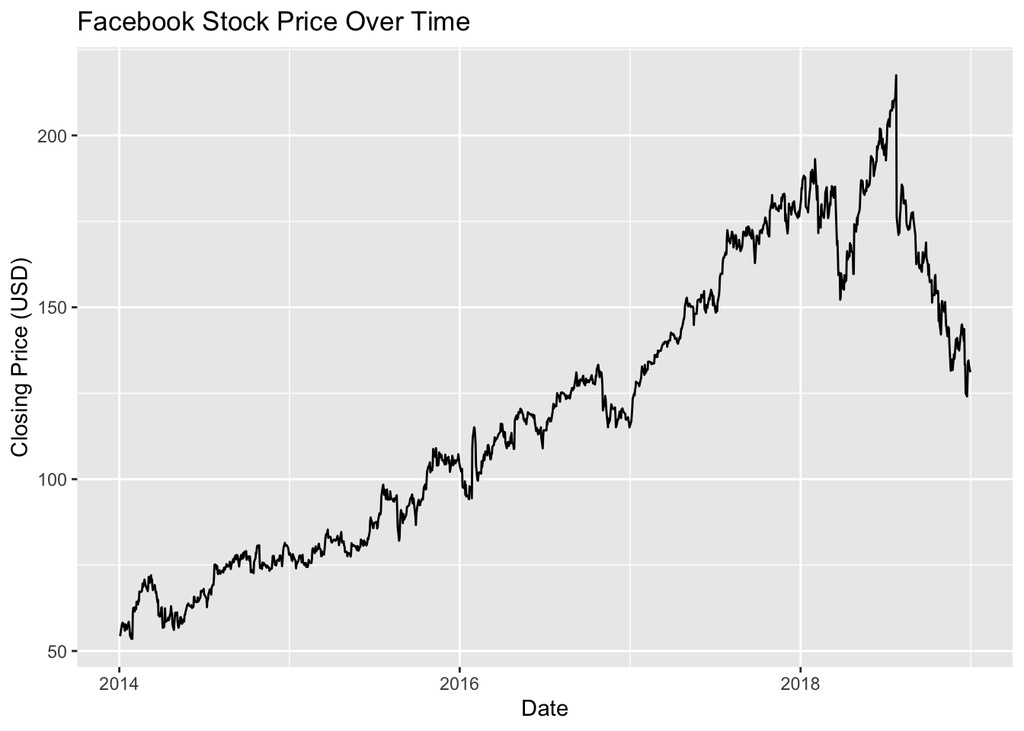

```r
facebook_stock <- gafa_stock |>
  filter(Symbol == "FB")

facebook_stock |>
  autoplot(Close) +
  labs(title = "Facebook Stock Price Over Time",
       y = "Closing Price (USD)",
       x = "Date")
```

The plot above shows that the closing price of Facebook stock is increasing from 2014 to 2018 and then declining significanty after that.

#### b) Produce forecasts using the drift method and plot them.

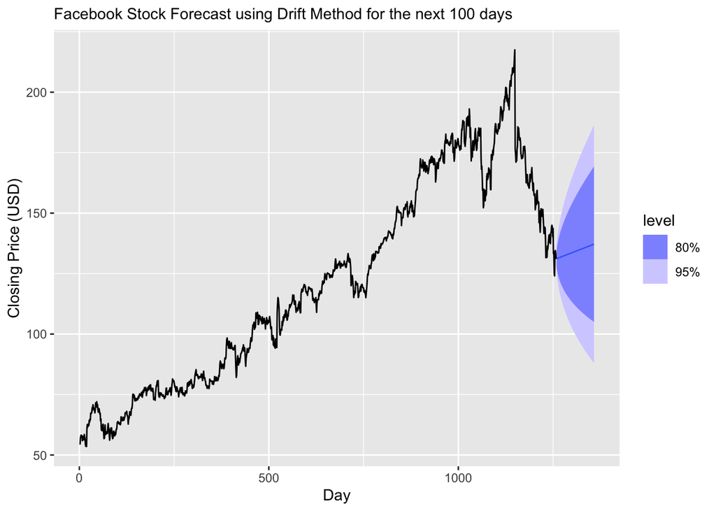

```r
facebook_stock <- facebook_stock |>
  mutate(day = row_number()) |>
  update_tsibble(index = day, regular = TRUE)

facebook_drift <- facebook_stock |>
  model(Drift = NAIVE(Close ~ drift()))

facebook_forecast <- facebook_drift |> forecast(h = 100)
facebook_forecast |> autoplot(facebook_stock) + labs(subtitle = "Facebook Stock Forecast using Drift Method for the next 100 days", y = "Closing Price (USD)",
       x = "Day")
```

The plot above shows that the forecast of Facebook’s stock price using the Drift Method, it seems like there will be a potential stabilization for the next 100 days.

#### c) Show that the forecasts are identical to extending the line drawn between the first and last observations.

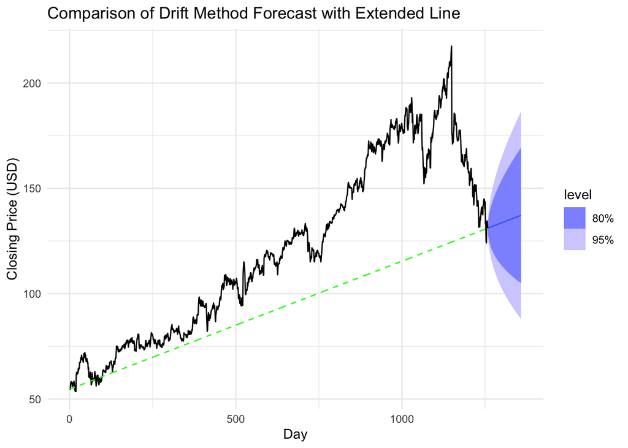

```r
#We calculate the slope (drift rate) to help us draw the line
fb_first <- first(facebook_stock$Close)
fb_last <- last(facebook_stock$Close)
fb_days <- nrow(facebook_stock)
slope <- (fb_last - fb_first) / (fb_days - 1)
facebook_stock <- facebook_stock |>
  mutate(Trend = fb_first + (row_number() - 1) * slope)

facebook_forecast |>
  autoplot(facebook_stock) +
  geom_line(aes(y = Trend), col = "green", linetype = "dashed") +
  labs(title = "Comparison of Drift Method Forecast with Extended Line",
       y = "Closing Price (USD)",
       x = "Day") +
  theme_minimal()
```

The plot above is the Drift Method forecast with a green dashed trend line, showing that the predicted stock price follows a long-term upward trend despite its ups and downs trend.

#### d) Try using some of the other benchmark functions to forecast the same data set. Which do you think is best? Why?

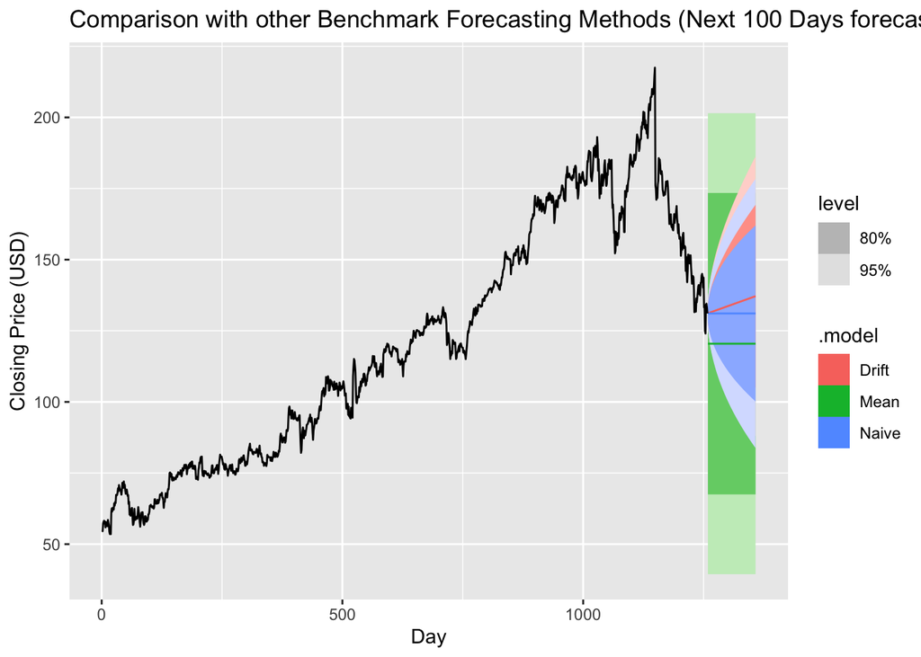

```r
# We then try to apply different benchmark methods like Mean and Naive
facebook_models <- facebook_stock |>
  model(
    Mean = MEAN(Close),
    Naive = NAIVE(Close),
    Drift = RW(Close ~ drift()),
  )

fb_forecasts <- facebook_models |>
  forecast(h = 100)
fb_forecasts |>
  autoplot(facebook_stock) +
  labs(title = "Comparison with other Benchmark Forecasting Methods (Next 100 Days forecasting)",
       y = "Closing Price (USD)",
       x = "Day")
```

```r
#We check the accuracy to see which method is the best
fb_accuracy <- facebook_models |>
  accuracy()
print(fb_accuracy)
```

```
## # A tibble: 3 × 11
##   Symbol .model .type         ME  RMSE   MAE      MPE  MAPE   MASE RMSSE    ACF1
##   <chr>  <chr>  <chr>      <dbl> <dbl> <dbl>    <dbl> <dbl>  <dbl> <dbl>   <dbl>
## 1 FB     Mean   Train… -1.56e-13 41.3  35.6  -1.36e+1 34.5  24.2   17.1   0.997
## 2 FB     Naive  Train…  6.08e- 2  2.41  1.47  5.15e-2  1.26  1.00   1    -0.0205
## 3 FB     Drift  Train…  0         2.41  1.46 -5.71e-3  1.26  0.998  1.00 -0.0205
```

The plot above compares Drift, Mean, and Naive forecasting methods, showing different predictions for Facebook’s stock price with different levels of uncertainty. The Drift method (red) follows the trend, the Mean method (green) stays around the average, and the Naive method (blue) keeps the last observed value, it shows how each method predicts the future differently.

From the accuracy table, we see that the **Drift method is the best** because it has the lowest RMSE, MAE and MAPE, it suggest that it makes the most accurate predictions. It also performs at least slightly better than the Naive method, which assumes no trend. The Mean method is not the best in this case since it has much higher errors. If the stock price has a trend, Drift is the best choice, but if prices are random, we can also consider using Naive method.

### 5.9

Hint: Create a training set for household wealth (please use variable Wealth in hh_budget dataset)

```r
hh_budget_ts <- hh_budget |>
  select(Year, Wealth) |>
  as_tsibble(index = Year)
```

#### a) Create a training set for household wealth (hh_budget) by withholding the last four years as a test set.

```r
# We split the training and test set by defining the training set, where we exclude last 4 years and the rest goes to test set
train <- hh_budget_ts |>
  filter(Year <= max(Year) - 4)
test <- hh_budget_ts |>
  filter(Year > max(Year) - 4)
```

#### b) Fit all the appropriate benchmark methods to the training set and forecast the periods covered by the test set.

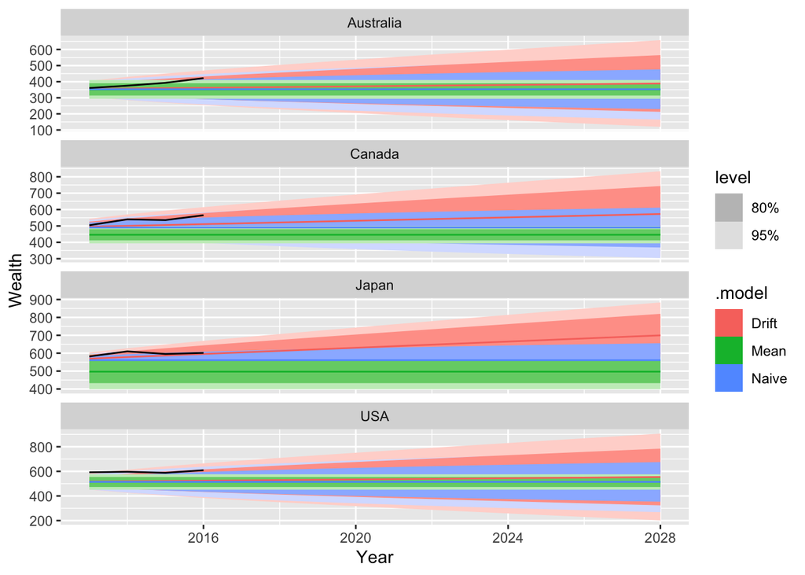

```r
benchmark_methods <- train |>
  model(
    Mean = MEAN(Wealth),
    Naive = NAIVE(Wealth),
    Drift = RW(Wealth ~ drift())
  )

wealth_forecasts <- benchmark_methods |>
  forecast(h = nrow(test))

wealth_forecasts |> autoplot(test)
```

The plot above compares Drift, Mean, and Naive forecasting methods to predict wealth in Australia, Canada, Japan, and the USA. The Drift method (red) shows an increase trend, it means that the wealth is expected to grow, while the Mean (green) and Naive (blue) methods predict more stable values. The red area gets wider over time, it suggesting that the Drift method has more uncertainty in long-term predictions.

#### c) Compute the accuracy of your forecasts. Which method does best?

```r
accuracy_results <- wealth_forecasts |>
  accuracy(test)
print(accuracy_results)
```

```
## # A tibble: 12 × 11
##    .model Country   .type    ME  RMSE   MAE   MPE  MAPE  MASE RMSSE    ACF1
##    <chr>  <chr>     <chr> <dbl> <dbl> <dbl> <dbl> <dbl> <dbl> <dbl>   <dbl>
##  1 Drift  Australia Test   29.1  35.5  29.1  7.23  7.23   NaN   NaN  0.210
##  2 Drift  Canada    Test   33.3  37.2  33.3  6.09  6.09   NaN   NaN -0.229
##  3 Drift  Japan     Test   14.7  17.9  14.7  2.44  2.44   NaN   NaN -0.229
##  4 Drift  USA       Test   75.9  76.2  75.9 12.7  12.7    NaN   NaN -0.561
##  5 Mean   Australia Test   35.7  42.3  35.7  8.89  8.89   NaN   NaN  0.216
##  6 Mean   Canada    Test   90.4  92.9  90.4 16.7  16.7    NaN   NaN -0.0799
##  7 Mean   Japan     Test  100.  101.  100.  16.8  16.8    NaN   NaN -0.534
##  8 Mean   USA       Test   82.9  83.3  82.9 13.9  13.9    NaN   NaN -0.423
##  9 Naive  Australia Test   34.7  41.5  34.7  8.64  8.64   NaN   NaN  0.216
## 10 Naive  Canada    Test   46.2  51.0  46.2  8.46  8.46   NaN   NaN -0.0799
## 11 Naive  Japan     Test   36.3  37.8  36.3  6.06  6.06   NaN   NaN -0.534
## 12 Naive  USA       Test   82.1  82.5  82.1 13.8  13.8    NaN   NaN -0.423
```

The table above shows the forecast accuracy results for the Drift, Mean, and Naive methods across four countries: Australia, Canada, Japan, and the USA. The Drift method generally has lower RMSE and MAE, which means it provides better predictions than the other methods.On the other hand, the Mean method has the highest errors, making it the least accurate. The Naive method performs better than the Mean method but is still not as good as Drift. Based on these results, **Drift is the best choice for forecasting wealth trends because it has lower error values in most cases**.

#### d) Do the residuals from the best method resemble white noise?

```
## Plot variable not specified, automatically selected `.vars = .resid`
```

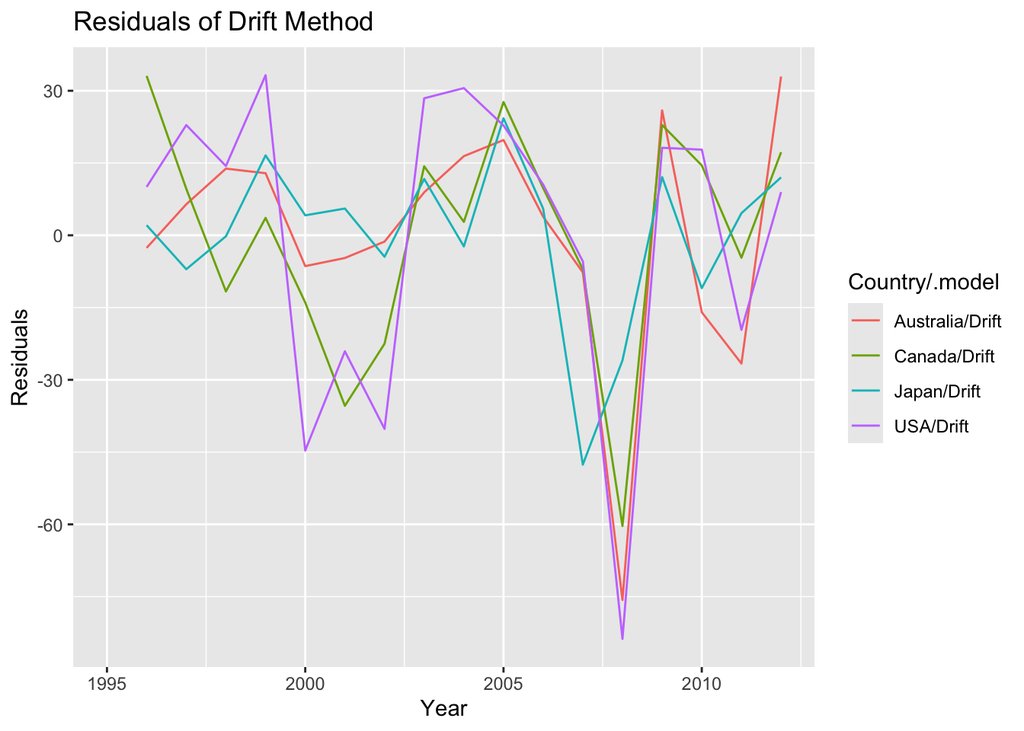

```r
drift_fit <- train |> model(Drift = RW(Wealth ~ drift()))
drift_residuals <- residuals(drift_fit)

autoplot(drift_residuals) +
  labs(title = "Residuals of Drift Method", y = "Residuals", x = "Year")
```

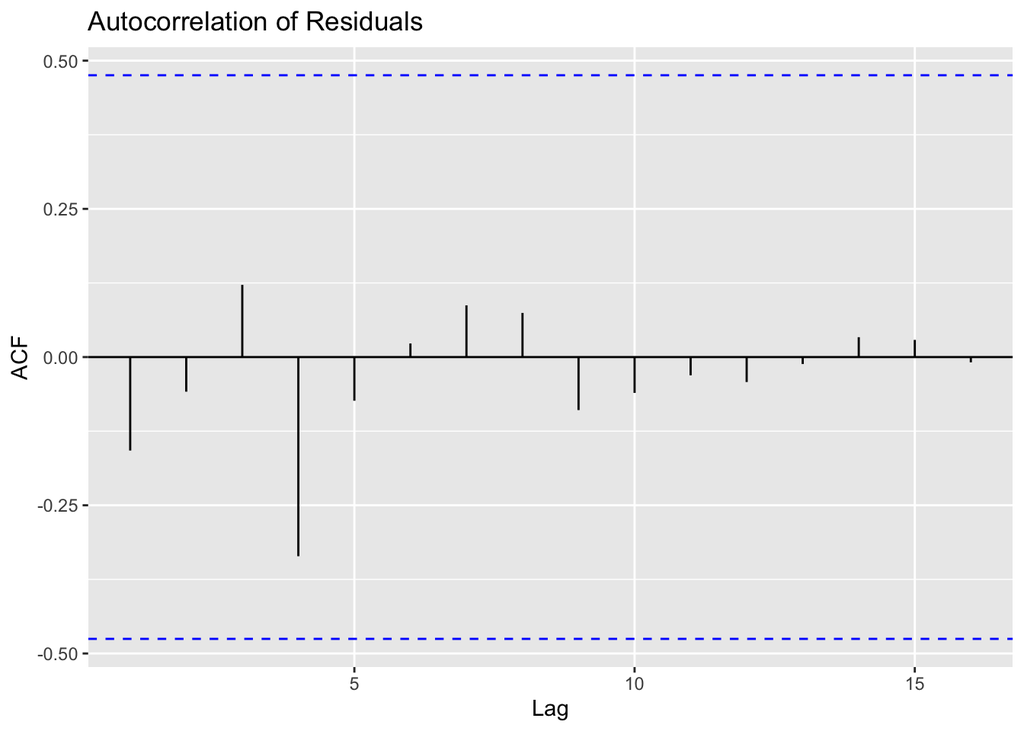

```r
ggAcf(drift_residuals$.resid) +
  labs(title = "Autocorrelation of Residuals")
```

```r
ljung_test <- drift_residuals |> features(.resid, ljung_box, lag = 10)
print(ljung_test)
```

```
## # A tibble: 4 × 4
##   Country   .model lb_stat lb_pvalue
##   <chr>     <chr>    <dbl>     <dbl>
## 1 Australia Drift     4.82     0.903
## 2 Canada    Drift     8.87     0.545
## 3 Japan     Drift     6.09     0.807
## 4 USA       Drift    12.9      0.229
```

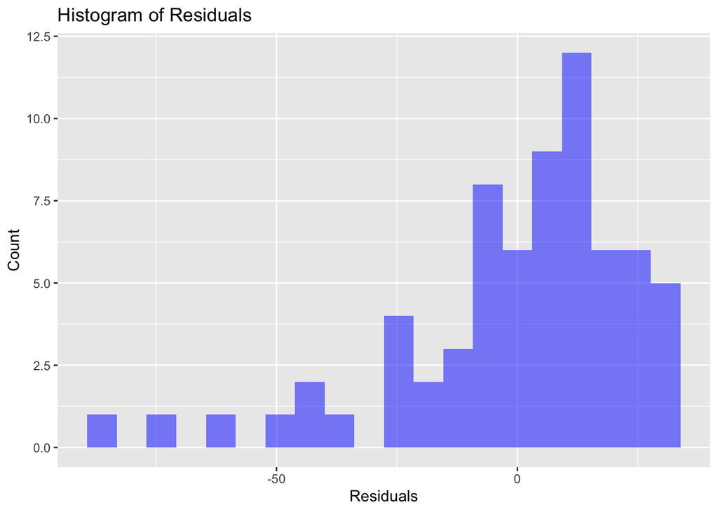

```r
ggplot(drift_residuals, aes(x = .resid)) +
  geom_histogram(bins = 20, fill = "blue", alpha = 0.5) +
  labs(title = "Histogram of Residuals", x = "Residuals", y = "Count")
```

```r
summary(drift_residuals$.resid)
```

```
##    Min. 1st Qu.  Median    Mean 3rd Qu.    Max.    NA's
## -83.770  -7.216   5.057   0.000  14.986  33.217       4
```

1. From the residual plot, we see that the residuals look random but also show some patterns.
2. In ACF plot, there is no strong correlations, which means that the past errors don’t affect future ones.
3. From histogram, we know that residuals are not perfectly normal because it showing some skewness.
4. After we perform the Ljung-Box Test, all p-values are above 0.05, which means there is no significant autocorrelation.

In conclusion, the residuals are mostly white noise, but some patterns remain. So far, the Drift method works well, but we can also consider any other advanced model to capture more details.